```python
# Loading necessary modules
import numpy as np
import pandas as pd
import matplotlib.pyplot as plt
import seaborn as sns
sns.set()

%matplotlib inline
```

# Unzip Fleet.zip using your File Explorer

After that you should have a folder 'Fleet', which contains the database Fleet.db

```python
# Open our Fleet.db database file using the SQLite database engine
# Change the following to be the path of your Fleet.db file
import sqlite3
connection = sqlite3.connect("Fleet.db")
print("Database connected")
```

```
Database connected
```

```python
# Execute a query, and return the result as a Pandas dataframe
# This database has one table called Fleet. This query gets the first 10 rows from Fleet
# Note: Not all columns are shown as we have so many!
dataframe = pd.read_sql_query('SELECT * FROM Fleet LIMIT 10', connection)
dataframe
```

|  | ALTERNATIVE_MOTIVE_POWER | BASIC_COLOUR | BODY_TYPE | CC_RATING | CHASSIS7 | CLASS | ENGINE_NUMBER | FIRST_NZ_REGISTRATION_YEAR | FIRST_NZ_REGISTRATION_MONTH | GROSS_VEHICLE_MASS | ... | ROAD_TRANSPORT_CODE | SUBMODEL | TLA | TRANSMISSION_TYPE | VDAM_WEIGHT | VEHICLE_TYPE | VEHICLE_USAGE | VEHICLE_YEAR | VIN11 | WIDTH |
| --- | --- | --- | --- | --- | --- | --- | --- | --- | --- | --- | --- | --- | --- | --- | --- | --- | --- | --- | --- | --- | --- |
| 0 |  | BLACK | SPORTS CAR | 5700 | 1G1YY12 | MA | COVERED | 2010 | 7 | 1610 | ... |  | Z06 | AUCKLAND |  | 0 | PASSENGER CAR/VAN | PRIVATE PASSENGER | 2003 | 1G1YY12S835 | 0 |
| 1 |  | BROWN | STATION WAGON | 1997 | NJ10-01 | MA | MR20-279818A | 2015 | 4 | 1765 | ... |  |  | TAURANGA CITY |  | 0 | PASSENGER CAR/VAN | PRIVATE PASSENGER | 2007 | 7AT0DH7HX15 | 0 |
| 2 |  | WHITE | OTHER TRUCK | 4100 | BU102-0 | NB | 15B-444597 | 2004 | 3 | 5750 | ... |  | BU102 | QUEENSTOWN-LAKES DISTRICT |  | 14200 | GOODS VAN/TRUCK/UTILITY | OTHER GOODS | 1996 | 7A8H60E0804 | 1920 |
| 3 |  | BLUE | MOTORCYCLE | 125 | CB125S- | LC | SL125SE-2001537 | 1973 | 2 | 0 | ... |  |  | DUNEDIN CITY |  | 0 | MOTORCYCLE | PRIVATE PASSENGER | 1973 | 7A88G341108 | 0 |
| 4 |  | BLACK | STATION WAGON | 2490 |  | MC | UNREADABLE | 2015 | 6 | 2035 | ... |  |  | CENTRAL OTAGO DISTRICT |  | 0 | PASSENGER CAR/VAN | PRIVATE PASSENGER | 2005 | WBAPA72080W | 0 |
| 5 |  | GREEN | CARAVAN | 0 |  | TA |  | 2004 | 11 | 0 | ... |  |  | KAIKOURA DISTRICT |  | 0 | TRAILER/CARAVAN | OTHER GOODS | 2004 | 6T9T21V9740 | 0 |
| 6 |  | BLUE | OTHER COMMERCIAL TRAILER | 0 | 023264 | TD |  | 2014 | 7 | 32000 | ... | STOCK CARTAGE |  | WAIMAKARIRI DISTRICT |  | 31000 | TRAILER/CARAVAN | TRANSPORT LICENSED GOODS | 2014 | 7A9E25013E1 | 2485 |
| 7 |  | BLACK | HATCHBACK | 1797 | ZSP110- | MA | 2ZRA083026 | 2015 | 6 | 1445 | ... |  |  | AUCKLAND |  | 0 | PASSENGER CAR/VAN | PRIVATE PASSENGER | 2007 | 7AT0H647X14 | 0 |
| 8 |  | ORANGE | STATION WAGON | 1998 |  | MC | G4NCEU455752 | 2015 | 5 | 2030 | ... |  | LTD 2.0P/4WD/6AT/SW | LOWER HUTT CITY | 6-GEAR AUTO | 0 | PASSENGER CAR/VAN | PRIVATE PASSENGER | 2015 | U5YPC81BSEL | 0 |
| 9 |  | SILVER | STATION WAGON | 1790 | ZGE20-0 | MA | 2ZR-0564774 | 2015 | 6 | 1725 | ... |  |  | AUCKLAND |  | 0 | PASSENGER CAR/VAN | PRIVATE PASSENGER | 2010 | 7AT0H64BX15 | 0 |

10 rows × 34 columns

```python
# Get the names of the columns using the SQLite "description".
connection.execute('select * from Fleet').description
```

```
(('ALTERNATIVE_MOTIVE_POWER', None, None, None, None, None, None),
 ('BASIC_COLOUR', None, None, None, None, None, None),
 ('BODY_TYPE', None, None, None, None, None, None),
 ('CC_RATING', None, None, None, None, None, None),
 ('CHASSIS7', None, None, None, None, None, None),
 ('CLASS', None, None, None, None, None, None),
 ('ENGINE_NUMBER', None, None, None, None, None, None),
 ('FIRST_NZ_REGISTRATION_YEAR', None, None, None, None, None, None),
 ('FIRST_NZ_REGISTRATION_MONTH', None, None, None, None, None, None),
 ('GROSS_VEHICLE_MASS', None, None, None, None, None, None),
 ('HEIGHT', None, None, None, None, None, None),
 ('IMPORT_STATUS', None, None, None, None, None, None),
 ('INDUSTRY_CLASS', None, None, None, None, None, None),
 ('INDUSTRY_MODEL_CODE', None, None, None, None, None, None),
 ('MAKE', None, None, None, None, None, None),
 ('MODEL', None, None, None, None, None, None),
 ('MOTIVE_POWER', None, None, None, None, None, None),
 ('MVMA_MODEL_CODE', None, None, None, None, None, None),
 ('NUMBER_OF_AXLES', None, None, None, None, None, None),
 ('NUMBER_OF_SEATS', None, None, None, None, None, None),
 ('NZ_ASSEMBLED', None, None, None, None, None, None),
 ('ORIGINAL_COUNTRY', None, None, None, None, None, None),
 ('POWER_RATING', None, None, None, None, None, None),
 ('PREVIOUS_COUNTRY', None, None, None, None, None, None),
 ('ROAD_TRANSPORT_CODE', None, None, None, None, None, None),
 ('SUBMODEL', None, None, None, None, None, None),
 ('TLA', None, None, None, None, None, None),
 ('TRANSMISSION_TYPE', None, None, None, None, None, None),
 ('VDAM_WEIGHT', None, None, None, None, None, None),
 ('VEHICLE_TYPE', None, None, None, None, None, None),
 ('VEHICLE_USAGE', None, None, None, None, None, None),
 ('VEHICLE_YEAR', None, None, None, None, None, None),
 ('VIN11', None, None, None, None, None, None),
 ('WIDTH', None, None, None, None, None, None))
```

```python
# Get the number of rows. This may take a while!
df = pd.read_sql_query('SELECT COUNT(*) FROM Fleet', connection)
df
```

|  | COUNT(*) |
| --- | --- |
| 0 | 5041543 |

```python
# How many Toyotas are there?
df = pd.read_sql_query('SELECT COUNT(*) FROM Fleet WHERE MAKE="TOYOTA"', connection)
df
```

|  | COUNT(*) |
| --- | --- |
| 0 | 967765 |

```python
# Display the number of cars of each MAKE for the first 100 makes
df = pd.read_sql_query('SELECT MAKE, COUNT(MAKE) FROM Fleet GROUP BY MAKE LIMIT 100', connection)
df
```

|  | MAKE | COUNT(MAKE) |
| --- | --- | --- |
| 0 | ABI | 208 |
| 1 | ABINGDON | 6 |
| 2 | AC | 25 |
| 3 | ACORN | 7 |
| 4 | ADAMS & CURRIE | 197 |
| ... | ... | ... |
| 95 | BROS | 3 |
| 96 | BROUGH | 7 |
| 97 | BSA | 1536 |
| 98 | BUCKLER | 13 |
| 99 | BUELL | 1077 |

100 rows × 2 columns

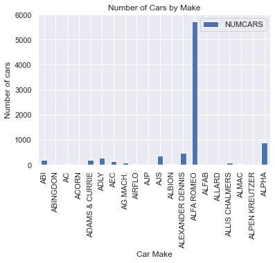

```python
# Plot the number of cars of each MAKE for the first 20 makes
sql = """SELECT MAKE, COUNT(MAKE) AS NUMCARS
            FROM Fleet GROUP BY MAKE LIMIT 20"""
df = pd.read_sql_query(sql, connection)
df.plot.bar(x='MAKE')
#trace = plotly.graph_objs.Bar(x=dataframe.MAKE,y=dataframe.NUMCARS)
plt.title("Number of Cars by Make")
plt.xlabel('Car Make')
plt.ylabel('Number of cars')
```

```python
# A query result column can be easily accessed using Python using dataframe.MAKE or dataframe.NUMCARS
for i in dataframe.MAKE:
    print(i)
```

```
CHEVROLET
NISSAN
TOYOTA
HONDA
BMW
CARAVAN
DOMETT
TOYOTA
KIA
TOYOTA
```

```python
# What is the smallest car?
# For simple answers, you do not need to create a DataFrame object
sql = """SELECT MIN(HEIGHT) AS MIN_HEIGHT FROM Fleet"""
pd.read_sql_query(sql, connection)
```

|  | MIN_HEIGHT |
| --- | --- |
| 0 | 0 |

## 1. What is the earliest year of first registration for the cars?

(2 marks)

```python
sql = 'SELECT MIN(FIRST_NZ_REGISTRATION_YEAR) AS FIRST_REG_YEAR FROM Fleet'
pd.read_sql_query(sql, connection)
#1899
```

|  | FIRST_REG_YEAR |
| --- | --- |
| 0 | 1899 |

## 2. What are the makes, models and vehicle year of all the cars with a vehicle year earlier than 1900?

(2 marks)

```python
sql = 'SELECT MAKE, MODEL, VEHICLE_YEAR FROM Fleet WHERE VEHICLE_YEAR<1900'
pd.read_sql_query(sql, connection)
# 15 results
```

|  | MAKE | MODEL | VEHICLE_YEAR |
| --- | --- | --- | --- |
| 0 | FACTORY BUILT | STANLEY STEAMER | 1899 |
| 1 | FACTORY BUILT | AVELING & PORTER | 1894 |
| 2 | VETERAN | RANSOMES SIMS & | 1899 |
| 3 | CARAVAN | CARAVAN | 1897 |
| 4 | FACTORY BUILT | FOWLER | 1892 |
| 5 | MOBILE MACHINE | HILL&MOORE CHUKWAGON | 1890 |
| 6 | MCLAREN | DCC | 1892 |
| 7 | LOCOMOBILE | 02 | 1899 |
| 8 | YAMAHA | RAZZ | 1898 |
| 9 | NISSAN | PH02 | 1898 |
| 10 | TRACTOR | FOWLER ENGINE | 1898 |
| 11 | DE DION-BOUTON | L 68 | 1898 |
| 12 | FACTORY BUILT | BURRELL TRACTION ENG | 1899 |
| 13 | VETERAN | LOC0MOBILE | 1899 |
| 14 | CUSTOMBUILT | FOWLER | 1896 |

## 3. What are the 10 most popular (by count) car makes, and the counts of these?

(2 marks)

```python
sql = """SELECT MAKE, COUNT(MAKE) AS NUMCARS FROM Fleet GROUP BY MAKE ORDER BY NUMCARS DESC LIMIT 10"""
pd.read_sql_query(sql, connection)
# Toyota most popular, then nissan, trailers, mazda, ford etc.
```

|  | MAKE | NUMCARS |
| --- | --- | --- |
| 0 | TOYOTA | 967765 |
| 1 | NISSAN | 491082 |
| 2 | TRAILER | 465880 |
| 3 | MAZDA | 347232 |
| 4 | FORD | 334040 |
| 5 | HONDA | 289657 |
| 6 | MITSUBISHI | 266473 |
| 7 | HOLDEN | 236895 |
| 8 | SUZUKI | 165627 |
| 9 | SUBARU | 132182 |

## 4. What are the 20 most popular (by count) car ‘models’, and the counts of these?

Note that we consider a ‘model’ to be defined by both the MAKE and MODEL fields, such as a ‘Holden’ ‘Commodore’. Therefore, your query needs to count each ‘make’, ‘model’ pair separately. (3 marks)

```python
sql = """SELECT MAKE, MODEL, COUNT(MODEL) AS NUMCARS FROM Fleet GROUP BY MAKE, MODEL ORDER BY NUMCARS DESC LIMIT 20"""
pd.read_sql_query(sql, connection)
# Toyota Corolla wins this unsurprisingly
```

|  | MAKE | MODEL | NUMCARS |
| --- | --- | --- | --- |
| 0 | TOYOTA | COROLLA | 170589 |
| 1 | TOYOTA | HILUX | 125273 |
| 2 | HOLDEN | COMMODORE | 86761 |
| 3 | TOYOTA | HIACE | 84895 |
| 4 | SUZUKI | SWIFT | 73171 |
| 5 | FORD | FALCON | 66504 |
| 6 | TOYOTA | RAV4 | 62660 |
| 7 | SUBARU | LEGACY | 61038 |
| 8 | TOYOTA | LANDCRUISER | 49277 |
| 9 | FORD | RANGER | 49024 |
| 10 | NISSAN | NAVARA | 47799 |
| 11 | TOYOTA | CAMRY | 45312 |
| 12 | TRAILER | HOMEBUILT | 45102 |
| 13 | HONDA | CIVIC | 43851 |
| 14 | MAZDA | DEMIO | 43786 |
| 15 | TRAILER | LOCAL | 42656 |
| 16 | VOLKSWAGEN | GOLF | 42210 |
| 17 | HONDA | ACCORD | 42040 |
| 18 | NISSAN | TIIDA | 41343 |
| 19 | MITSUBISHI | LANCER | 40174 |

## 5. How many cars are first registered in each of the most recent 50 years?

You may end up with a NULL year in your result, meaning only 49 years are actually shown; that is ok in this answer, and also in your later answers. (3 marks)

```python
sql = """SELECT FIRST_NZ_REGISTRATION_YEAR, COUNT(FIRST_NZ_REGISTRATION_YEAR) AS NUM_CARS_REG FROM Fleet
            GROUP BY FIRST_NZ_REGISTRATION_YEAR ORDER BY FIRST_NZ_REGISTRATION_YEAR DESC LIMIT 50"""
reg_by_year = pd.read_sql_query(sql, connection)
reg_by_year
# More recent years have more cars registered
```

|  | FIRST_NZ_REGISTRATION_YEAR | NUM_CARS_REG |
| --- | --- | --- |
| 0 |  | 236 |
| 1 | 2017 | 370431 |
| 2 | 2016 | 367856 |
| 3 | 2015 | 340006 |
| 4 | 2014 | 308933 |
| 5 | 2013 | 255464 |
| 6 | 2012 | 213171 |
| 7 | 2011 | 193042 |
| 8 | 2010 | 190921 |
| 9 | 2009 | 161670 |
| 10 | 2008 | 215344 |
| 11 | 2007 | 238951 |
| 12 | 2006 | 222354 |
| 13 | 2005 | 230420 |
| 14 | 2004 | 213841 |
| 15 | 2003 | 193299 |
| 16 | 2002 | 155648 |
| 17 | 2001 | 124508 |
| 18 | 2000 | 109571 |
| 19 | 1999 | 104397 |
| 20 | 1998 | 83854 |
| 21 | 1997 | 79866 |
| 22 | 1996 | 75864 |
| 23 | 1995 | 61618 |
| 24 | 1994 | 52136 |
| 25 | 1993 | 40001 |
| 26 | 1992 | 33478 |
| 27 | 1991 | 30970 |
| 28 | 1990 | 35055 |
| 29 | 1989 | 27974 |
| 30 | 1988 | 21478 |
| 31 | 1987 | 21236 |
| 32 | 1986 | 18404 |
| 33 | 1985 | 16201 |
| 34 | 1984 | 14749 |
| 35 | 1983 | 11957 |
| 36 | 1982 | 12086 |
| 37 | 1981 | 11864 |
| 38 | 1980 | 12143 |
| 39 | 1979 | 12334 |
| 40 | 1978 | 12083 |
| 41 | 1977 | 12149 |
| 42 | 1976 | 12262 |
| 43 | 1975 | 11655 |
| 44 | 1974 | 13027 |
| 45 | 1973 | 11813 |
| 46 | 1972 | 9627 |
| 47 | 1971 | 8324 |
| 48 | 1970 | 7440 |
| 49 | 1969 | 5527 |

## 6. Generate a labelled bar graph plot of the previous answer (with the dates in ascending order).

(3 marks)

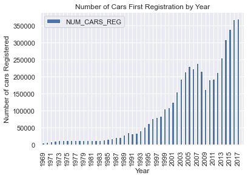

```python
rev = reg_by_year.iloc[::-1]
# Reverse dataframe to plot ascending
rev.plot.bar(x='FIRST_NZ_REGISTRATION_YEAR', y='NUM_CARS_REG')
plt.title("Number of Cars First Registration by Year")
plt.xlabel('Year')
plt.ylabel('Number of cars Registered')
# Code from the web to clean up the x-labels by only displaying every 2nd year-label
ax = plt.gca()
temp = ax.xaxis.get_ticklabels()
temp = list(set(temp) - set(temp[::2]))
for label in temp:
    label.set_visible(False)
```

## 7. How many Toyota cars were first registered in each year from 1950 onwards?

Hint: You can use AND to join together multiple tests in a WHERE. (3 marks)

```python
sql = """SELECT FIRST_NZ_REGISTRATION_YEAR, COUNT(FIRST_NZ_REGISTRATION_YEAR) AS NUM_TOYOTA_REG FROM Fleet
        WHERE MAKE='TOYOTA' AND FIRST_NZ_REGISTRATION_YEAR>=1950
            GROUP BY FIRST_NZ_REGISTRATION_YEAR ORDER BY FIRST_NZ_REGISTRATION_YEAR"""
toy_by_year = pd.read_sql_query(sql, connection)
toy_by_year
# First toyota in 1966
```

|  | FIRST_NZ_REGISTRATION_YEAR | NUM_TOYOTA_REG |
| --- | --- | --- |
| 0 | 1966 | 1 |
| 1 | 1967 | 8 |
| 2 | 1968 | 5 |
| 3 | 1969 | 28 |
| 4 | 1970 | 91 |
| 5 | 1971 | 131 |
| 6 | 1972 | 205 |
| 7 | 1973 | 220 |
| 8 | 1974 | 356 |
| 9 | 1975 | 278 |
| 10 | 1976 | 341 |
| 11 | 1977 | 333 |
| 12 | 1978 | 425 |
| 13 | 1979 | 490 |
| 14 | 1980 | 603 |
| 15 | 1981 | 794 |
| 16 | 1982 | 1032 |
| 17 | 1983 | 1131 |
| 18 | 1984 | 1610 |
| 19 | 1985 | 1636 |
| 20 | 1986 | 1399 |
| 21 | 1987 | 1419 |
| 22 | 1988 | 2397 |
| 23 | 1989 | 3954 |
| 24 | 1990 | 7046 |
| 25 | 1991 | 5889 |
| 26 | 1992 | 7074 |
| 27 | 1993 | 9932 |
| 28 | 1994 | 11861 |
| 29 | 1995 | 14075 |
| 30 | 1996 | 16882 |
| 31 | 1997 | 17454 |
| 32 | 1998 | 16419 |
| 33 | 1999 | 21196 |
| 34 | 2000 | 21076 |
| 35 | 2001 | 24656 |
| 36 | 2002 | 33583 |
| 37 | 2003 | 44167 |
| 38 | 2004 | 46482 |
| 39 | 2005 | 50686 |
| 40 | 2006 | 46622 |
| 41 | 2007 | 49991 |
| 42 | 2008 | 42825 |
| 43 | 2009 | 31288 |
| 44 | 2010 | 39824 |
| 45 | 2011 | 38230 |
| 46 | 2012 | 41409 |
| 47 | 2013 | 49253 |
| 48 | 2014 | 57738 |
| 49 | 2015 | 61919 |
| 50 | 2016 | 68532 |
| 51 | 2017 | 72768 |
| 52 |  | 1 |

## 8. How many cars from Japan (ORIGINAL_COUNTRY=”JAPAN”) were first registered in each year from 1950 onwards?

(marks 3)

```python
sql = """SELECT FIRST_NZ_REGISTRATION_YEAR, COUNT(FIRST_NZ_REGISTRATION_YEAR) AS NUM_JAP_CARS_REG FROM Fleet
        WHERE ORIGINAL_COUNTRY='JAPAN' AND FIRST_NZ_REGISTRATION_YEAR>=1950
            GROUP BY FIRST_NZ_REGISTRATION_YEAR ORDER BY FIRST_NZ_REGISTRATION_YEAR"""
jap_by_year = pd.read_sql_query(sql, connection)
jap_by_year = jap_by_year[:-1]  #Remove null row
jap_by_year
# Lots
```

|  | FIRST_NZ_REGISTRATION_YEAR | NUM_JAP_CARS_REG |
| --- | --- | --- |
| 0 | 1950 | 1 |
| 1 | 1952 | 1 |
| 2 | 1957 | 1 |
| 3 | 1958 | 2 |
| 4 | 1960 | 8 |
| ... | ... | ... |
| 57 | 2013 | 123021 |
| 58 | 2014 | 153308 |
| 59 | 2015 | 167140 |
| 60 | 2016 | 175471 |
| 61 | 2017 | 183069 |

62 rows × 2 columns

## 9. How many cars from Germany were first registered in each year from 1950 onwards?

(3 marks)

```python
sql = """SELECT FIRST_NZ_REGISTRATION_YEAR, COUNT(FIRST_NZ_REGISTRATION_YEAR) AS NUM_GER_CARS_REG FROM Fleet
        WHERE ORIGINAL_COUNTRY='GERMANY' AND FIRST_NZ_REGISTRATION_YEAR>=1950
            GROUP BY FIRST_NZ_REGISTRATION_YEAR ORDER BY FIRST_NZ_REGISTRATION_YEAR"""
ger_by_year = pd.read_sql_query(sql, connection)
ger_by_year = ger_by_year[:-1]  #Remove null row
ger_by_year
# Quite a lot less recently
```

|  | FIRST_NZ_REGISTRATION_YEAR | NUM_GER_CARS_REG |
| --- | --- | --- |
| 0 | 1951 | 1 |
| 1 | 1952 | 3 |
| 2 | 1953 | 1 |
| 3 | 1954 | 17 |
| 4 | 1955 | 13 |
| ... | ... | ... |
| 62 | 2013 | 20431 |
| 63 | 2014 | 25684 |
| 64 | 2015 | 27621 |
| 65 | 2016 | 28784 |
| 66 | 2017 | 29059 |

67 rows × 2 columns

## 10. Generate a labelled barplot (with a legend) showing all first-registered data for Japan and Germany.

Hint: Combine the results from the previous two questions with `pd.merge()`.

(3 marks)

[figure not shown]

```python
joined = pd.merge(jap_by_year, ger_by_year, how='outer', on="FIRST_NZ_REGISTRATION_YEAR")
joined = joined.astype({'FIRST_NZ_REGISTRATION_YEAR':'int'})
#joined = joined['FIRST_NZ_REGISTRATION_YEAR'>2000]
joined.sort_values('FIRST_NZ_REGISTRATION_YEAR', inplace=True)

joined.plot.bar(x='FIRST_NZ_REGISTRATION_YEAR')
plt.title("Number of Cars First Registration by Year")
plt.xlabel('Year')
plt.ylabel('Number of cars Registered')
# Code from the web to clean up the x-labels by only displaying every 3rd year-label
ax = plt.gca()
temp = ax.xaxis.get_ticklabels()
temp = list(set(temp) - set(temp[::3]))
for label in temp:
    label.set_visible(False)
```